# Markov Chain Monte Carlo

In the last decade, we have seen an explosion of impressive results in Machine Learning, producing models that match and even sometimes outperform humans on [challenging tasks](https://drive.google.com/open?id=1vAdNe_bZ-KG-tzkhYIr3qXtT6gYcWjNX). A non-trivial part of the challenge in developing these models is not in specifying how they should solve the problems they are developed solve, but in figuring out how to actually derive predictions from these models.

Earlier this quarter, we read a paper from [John Anderson](https://drive.google.com/open?id=1IyLlUiL1-5OGwJewc5cMcUkapJg4zAMi) that shows how human category learning can be understood through the lens of rational analysis. Because the model does not have an analytic solution, A large section of this article involves deriving approximation methods for determining approximately what the model predicts. However, Anderson’s approximations actually undersell how well his model predicts human behavior–more recent work from [Sanborn, Griffiths, and Navarro (2010)](https://drive.google.com/open?id=1c8XdkPzzP3gziemsvdvb0fr3flo2JATI) shows that simulating Anderson’s model rather than approximating it actually produces a better match to how people categorize.

The approach that Sanborn et al. use, and that is a mainstay in modern Bayesian approaches, is technique called Markov Chain Monte Carlo (MCMC). Markov Chain Monte Carlo is a method for approximating samples from a complex Distribution (e.g. the Posterior category membership distribution from Anderson (1991)) by drawing samples from other simpler distributions and reweighing or combining them together.

In this assigmnent, you will implement the Metropolis-Hastings Algorithm, an MCMC algorithm in the Rejection Sampling family. In this family of algorithms, samples are drawn from a simple Proposal distribution and then either Accepted (if they have high probablity under the target distribution), or Rejected.

# The Metropolis-Hastings Algorithm

Metropolis-Hastings is a simple rejection sampling scheme for drawing samples from a target distribution $P\left(x\right)$ by using a density function $f\left(x\right)$ that is proportional to $P$– i.e., that can give the relative probability of two different samples $x$ and $x'$.

The algorithm works by starting a chain at some arbitrary point $x0$. Then, in each iteration $t$, a new sample $x1$ by modifying the previous sample $x_{t}$ according to a proposal distribution $g\left(x'|x_{t}\right)$. The critical requirement is that $g$ is a symmetric distribution $g\left(x'|x\right) = g\left(x|x'\right)$.

For your simulation, you should use a simple Normal distirbution centered at the previous sample $g\left(x'|x\right) \sim \text{Normal}\left(x, \sigma\right)$.

You then run the algorithm for some number of iterations, e.g. 1000, at each iteration performing the following steps:

1. Propose a new sample $x'$ by drawing from $g\left(x'|x_{t}\right)$
2. Compute the acceptance ratio $\alpha = \frac{f\left(x'\right)}{f\left(x\right)}$
3. Sample $u \sim \text{Uniform}\left(0,1\right)$.

   If $u \leq \alpha$, accept the proposed sample ($x_{t+1} = x'$).

   Otherwise, reject the proposed sample and keep the previous sample ($x_{t+1} = x_{t}$).

## Sampling from an Exponential Distirbution

Exponential distributions are a common distribution in models of cognition, for example they are sometimes used to model forgetting in memory. The Exponential distribution has one parameter $\lambda$ which defines the rate of decay (or forgetting).

If $x \sim \text{Exponential}\left(\lambda\right)$, $P\left(x\right) = \lambda e^{-\lambda x}$.

**R** actually can draw samples from an Exponential distribution. For example, here are 1000 samples from $\text{Exponential}\left(3\right)$

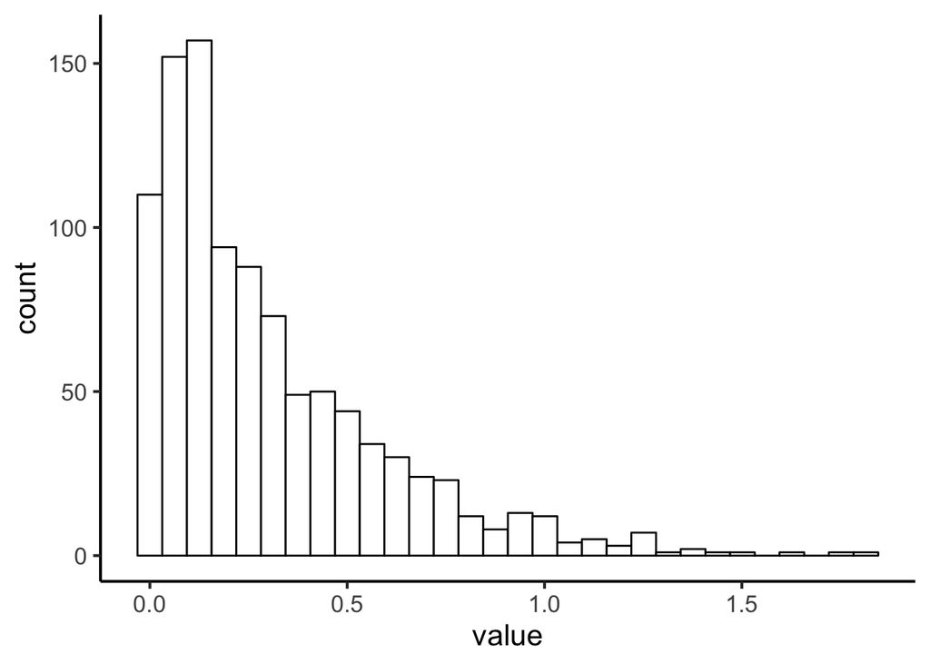

```r
samples <- tibble(sample = 1:1000, value = rexp(1000, rate = 3))

ggplot(samples, aes(x = value)) +
  geom_histogram(fill = "white", color = "black")
```

But let’s see how can draw samples from an exponential distribution using Metropolis-Hastings samples instead.

You will need to do 3 things: 1. Define the Exponential target distribution $f(x)$ using the Exponential definition above. 2. Define the proposal distribution $g(x'|x)$ 3. Define and Metropolis-Hastings rejection sampling algorithm 4. Run the Algorithm for some number of iterations and plot the results.

One thing you might notice is that the Metropolis-Hastings samples won’t look like Exponential samples right away. Here is a plot of $f(x)$ for 1000 samples from Metropolis-Hastings:

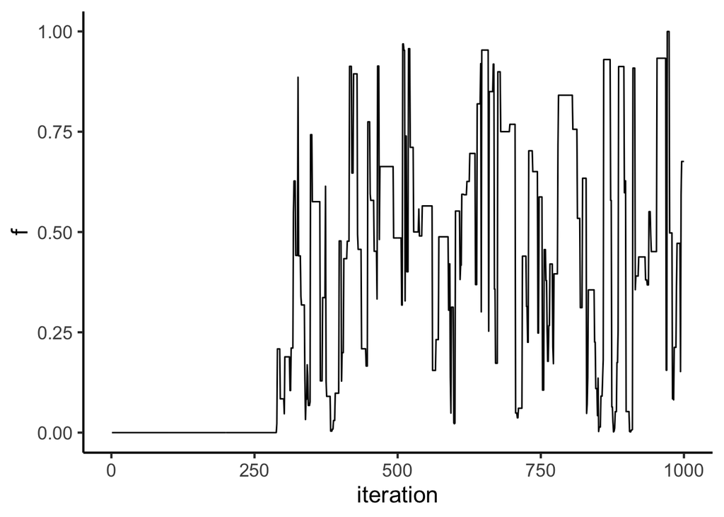

```r
ggplot(output, aes(x = iteration, y = f)) +
  geom_line()
```

You can see that first several hundred samples, every sample has low probability under the target distribution. This happens when the starting point of the chain is far away from the area of high density in the target distribution. For this reason, it is common to discard some of the initial samples–a process called **burn in**. You may find this helpful in future simulations.

## Sampling from a Dirichlet Distirbution

The Dirichlet Distribution is a highly flexible distribution that is that can many different forms depending on its parameters. It often finds use in Cognitive models precisely when the goal is to learn about something than has unknown shape before learning starts (e.g. the probability of category membership given some set of features). It’s also not available in the **R** statistics library. You can sample from it using MCMC!

The Dirichlet distribution takes $K \geq 2$ parameters (corresonding to separate dimensions) which are commonly represented as a vector $\boldsymbol \alpha$. Each $\alpha_{i} \geq 0$ is a concentration parameter which specifies how much of the probability mass of the function is concentrated on that dimension.

For a vector $\boldsymbol x$,

$$\text{Dirichlet}(\boldsymbol x) = \frac{1}{B\left(\boldsymbol\alpha\right)} \prod_{i=1}^{K}{x_{i}^{\alpha_{i} - 1}}$$

Where $B$ is a normalizing constants: The $Beta$ function

$$\text{Beta}(\boldsymbol \alpha) = \frac{\prod_{i=1}^{K}{\Gamma\left(\alpha_{i}\right)}}{\Gamma\left(\sum_{i=1}^{K}\alpha_{i}\right)}$$

And $\Gamma$ is the continous generalization of the factorial ($x!$) function. You can call it in **R** with `gamma(x)`

You can use Metropolis-Hastings to sample from the Dirichlet distribution in the same way you did for the Exponential distribution with one wrinkle: You need a different proposal distribution. The exponential distribution is defined over all positive real numbers, so you used Gaussian proposals and simply cut the distribution off when $x < 0$. However, the Dirichlet distribution is defined only owhen the value on every dimension is between 0 and 1, and the sum of the values across the dimensions adds up to 1 (this is called a simplex). So if you try to make Gaussian proposals, almost every proposal will be rejected because the Dirichlet distribution will give probability 0 for it.

Instead, you can use a proposal function where you generate values from a uniform distribution between a small negative and small positive fraction, and this fraction to one dimension while subtracting it from the other. This will keep your xs in the desired range.

## Inference via Markov Chain Monte Carlo

In addition to it’s utility in sampling from complex distributions, MCMC is a powerful tool for inference in these same distributions. If we have samples from a distribution with uknown parameters, we can use MCMC to infer the parameters that generated it (e.g. we can infer the category structure most likely to have produced the exemplars we observed).

In the final part of the assignment, you will use Metropolis-Hastings to infer the unknown parameters of a Dirichlet distribution from a set of samples from it. To do this, we will leverage Bayes’ rule: $P\left(H|D\right) \propto P\left(D|H\right)P(H)$. In the previous section, you used the likelihood function for a known Dirichlet distribution $P(D|H)$ in order to draw samples from it. Now you will use that same likelihood function for inference. The intuition here is that the parameters that assign high probability to a given sample are more likely to have been the source of that sample.

In the previous sections, in each iteration you proposed a sample from the distribution and rejected it if it was not sufficiently likely. Now, you will propose hypothetical parameters for the distribution, and reject them if they do not make the sample sufficiently likely.

The homework template will provide you 100 samples from this unkown Dirichlet distribution and your job will be to recover the paramters that generated it. Think carefully about the proposal distribution you wanto to use here. Remember, each proposal will now move you around on the parameter space of the Dirichlet distribution–not the space of values produced by the Dirichlet.

## Homework Content

1. **Exponential Distribution Preliminiaries (10 Points):** Implement the Exponential probability distribution and the Gaussian proposal function
2. **Metropolis-Hastings for an Exponential (20 Points)** Implement a Metropolis-Hastings sampler for an Exponential distribution and use it draw 1000 samples from an Exponential distribution with $\lambda=3$. Try $\lambda=1$ as well. Do the distributions look different?
3. **Dirichlet Distribution Preliminiaries (15 Points)** Implement the Beta function, the Dirichlet distribution probability function, and the Delta proposal function
4. **Metropolis-Hastings for a Dirichlet (20 Points)** Implement a Metropolis-Hastings sampler for a Dirichlet distribution and use it draw samples from a Dirichlet distribution with $\alpha = <.7,4>$. How many burn in samples do you need before the chain stablizes?
5. **MCMC Inference preliminaries (15 Points)** Implement the compound Dirichlet probability function and an appropriate propsal function.
6. **Infer the unknown parameters (20 Points)** Run your new MCMC sampler to determine the generating paramters. You may need to play around a bit with proposal distributions and number of samples/burnin.

### Report format

**R Markdown:** All code used to generate the results and plots should be organized and submitted in an R Markdown document.

Download the template for this homework here:

```r
download.file("https://raw.githubusercontent.com/dyurovsky/cog-models/master/hw3_template.Rmd",
              destfile = "hw3_template.Rmd")
```

### Teamwork and grading

You will be allowed to work with up to two other member of the class and submit on the project. You can either choose your partner(s), or if you’d prefer I’m happy to choose a partner(s) for you. You’re also welcome to work alone if you prefer.

All partners will receive the same grade.